# Lab_2

0. Import the data and declare your package dependencies.

```python
import pandas as pd
from plotnine import ggplot, aes, geom_boxplot, labs, theme, element_text, scale_y_continuous, geom_bar, facet_grid, geom_point, geom_smooth
```

```python
avo_clean = pd.read_csv("avocado-updated-2020.csv")
avo_clean.head()
```

|  | date | average_price | total_volume | 4046 | 4225 | 4770 | total_bags | small_bags | large_bags | xlarge_bags | type | year | geography |
| --- | --- | --- | --- | --- | --- | --- | --- | --- | --- | --- | --- | --- | --- |
| 0 | 2015-01-04 | 1.22 | 40873.28 | 2819.50 | 28287.42 | 49.90 | 9716.46 | 9186.93 | 529.53 | 0.0 | conventional | 2015 | Albany |
| 1 | 2015-01-04 | 1.79 | 1373.95 | 57.42 | 153.88 | 0.00 | 1162.65 | 1162.65 | 0.00 | 0.0 | organic | 2015 | Albany |
| 2 | 2015-01-04 | 1.00 | 435021.49 | 364302.39 | 23821.16 | 82.15 | 46815.79 | 16707.15 | 30108.64 | 0.0 | conventional | 2015 | Atlanta |
| 3 | 2015-01-04 | 1.76 | 3846.69 | 1500.15 | 938.35 | 0.00 | 1408.19 | 1071.35 | 336.84 | 0.0 | organic | 2015 | Atlanta |
| 4 | 2015-01-04 | 1.08 | 788025.06 | 53987.31 | 552906.04 | 39995.03 | 141136.68 | 137146.07 | 3990.61 | 0.0 | conventional | 2015 | Baltimore/Washington |

1. Briefly describe the data set. What information does it contain?

2. Clean the data in any way you see fit.

```python
# Finding each unique place in the dataset
avo_clean["geography"].unique()
```

```
array(['Albany', 'Atlanta', 'Baltimore/Washington', 'Boise', 'Boston',
       'Buffalo/Rochester', 'California', 'Charlotte', 'Chicago',
       'Cincinnati/Dayton', 'Columbus', 'Dallas/Ft. Worth', 'Denver',
       'Detroit', 'Grand Rapids', 'Great Lakes', 'Harrisburg/Scranton',
       'Hartford/Springfield', 'Houston', 'Indianapolis', 'Jacksonville',
       'Las Vegas', 'Los Angeles', 'Louisville', 'Miami/Ft. Lauderdale',
       'Midsouth', 'Nashville', 'New Orleans/Mobile', 'New York',
       'Northeast', 'Northern New England', 'Orlando', 'Philadelphia',
       'Phoenix/Tucson', 'Pittsburgh', 'Plains', 'Portland',
       'Raleigh/Greensboro', 'Richmond/Norfolk', 'Roanoke', 'Sacramento',
       'San Diego', 'San Francisco', 'Seattle', 'South Carolina',
       'South Central', 'Southeast', 'Spokane', 'St. Louis', 'Syracuse',
       'Tampa', 'Total U.S.', 'West', 'West Tex/New Mexico'], dtype=object)
```

```python
# I used AI in order to speed up this step rather than do each place by hand (also takes away chance for human error)
# Dictionary mapping each geography to its type
geo_type_map = {
    'Albany': 'city',
    'Atlanta': 'city',
    'Baltimore/Washington': 'city',
    'Boise': 'city',
    'Boston': 'city',
    'Buffalo/Rochester': 'city',
    'California': 'state',
    'Charlotte': 'city',
    'Chicago': 'city',
    'Cincinnati/Dayton': 'city',
    'Columbus': 'city',
    'Dallas/Ft. Worth': 'city',
    'Denver': 'city',
    'Detroit': 'city',
    'Grand Rapids': 'city',
    'Great Lakes': 'region',
    'Harrisburg/Scranton': 'city',
    'Hartford/Springfield': 'city',
    'Houston': 'city',
    'Indianapolis': 'city',
    'Jacksonville': 'city',
    'Las Vegas': 'city',
    'Los Angeles': 'city',
    'Louisville': 'city',
    'Miami/Ft. Lauderdale': 'city',
    'Midsouth': 'region',
    'Nashville': 'city',
    'New Orleans/Mobile': 'city',
    'New York': 'city',
    'Northeast': 'region',
    'Northern New England': 'city',
    'Orlando': 'city',
    'Philadelphia': 'city',
    'Phoenix/Tucson': 'city',
    'Pittsburgh': 'city',
    'Plains': 'region',
    'Portland': 'city',
    'Raleigh/Greensboro': 'city',
    'Richmond/Norfolk': 'city',
    'Roanoke': 'city',
    'Sacramento': 'city',
    'San Diego': 'city',
    'San Francisco': 'city',
    'Seattle': 'city',
    'South Carolina': 'city',
    'South Central': 'region',
    'Southeast': 'region',
    'Spokane': 'city',
    'St. Louis': 'city',
    'Syracuse': 'city',
    'Tampa': 'city',
    'Total U.S.': 'us',
    'West': 'region',
    'West Tex/New Mexico': 'city'
}
```

```python
avo_clean['geo_type'] = avo_clean['geography'].map(geo_type_map)
avo_clean.head()
```

|  | date | average_price | total_volume | 4046 | 4225 | 4770 | total_bags | small_bags | large_bags | xlarge_bags | type | year | geography | geo_type |
| --- | --- | --- | --- | --- | --- | --- | --- | --- | --- | --- | --- | --- | --- | --- |
| 0 | 2015-01-04 | 1.22 | 40873.28 | 2819.50 | 28287.42 | 49.90 | 9716.46 | 9186.93 | 529.53 | 0.0 | conventional | 2015 | Albany | city |
| 1 | 2015-01-04 | 1.79 | 1373.95 | 57.42 | 153.88 | 0.00 | 1162.65 | 1162.65 | 0.00 | 0.0 | organic | 2015 | Albany | city |
| 2 | 2015-01-04 | 1.00 | 435021.49 | 364302.39 | 23821.16 | 82.15 | 46815.79 | 16707.15 | 30108.64 | 0.0 | conventional | 2015 | Atlanta | city |
| 3 | 2015-01-04 | 1.76 | 3846.69 | 1500.15 | 938.35 | 0.00 | 1408.19 | 1071.35 | 336.84 | 0.0 | organic | 2015 | Atlanta | city |
| 4 | 2015-01-04 | 1.08 | 788025.06 | 53987.31 | 552906.04 | 39995.03 | 141136.68 | 137146.07 | 3990.61 | 0.0 | conventional | 2015 | Baltimore/Washington | city |

```python
# Renaming columns to be more understandble to readers
avo_clean = avo_clean.rename(columns={
    '4046': 'total_small_avocados',
    '4225': 'total_medium_avocados',
    '4770': 'total_large_avocados',
    'type': 'type (C / O)'
})
avo_clean.head()
```

|  | date | average_price | total_volume | total_small_avocados | total_medium_avocados | total_large_avocados | total_bags | small_bags | large_bags | xlarge_bags | type (C / O) | year | geography | geo_type |
| --- | --- | --- | --- | --- | --- | --- | --- | --- | --- | --- | --- | --- | --- | --- |
| 0 | 2015-01-04 | 1.22 | 40873.28 | 2819.50 | 28287.42 | 49.90 | 9716.46 | 9186.93 | 529.53 | 0.0 | conventional | 2015 | Albany | city |
| 1 | 2015-01-04 | 1.79 | 1373.95 | 57.42 | 153.88 | 0.00 | 1162.65 | 1162.65 | 0.00 | 0.0 | organic | 2015 | Albany | city |
| 2 | 2015-01-04 | 1.00 | 435021.49 | 364302.39 | 23821.16 | 82.15 | 46815.79 | 16707.15 | 30108.64 | 0.0 | conventional | 2015 | Atlanta | city |
| 3 | 2015-01-04 | 1.76 | 3846.69 | 1500.15 | 938.35 | 0.00 | 1408.19 | 1071.35 | 336.84 | 0.0 | organic | 2015 | Atlanta | city |
| 4 | 2015-01-04 | 1.08 | 788025.06 | 53987.31 | 552906.04 | 39995.03 | 141136.68 | 137146.07 | 3990.61 | 0.0 | conventional | 2015 | Baltimore/Washington | city |

3. Which major geographical region sold the most total organic, small Hass avocados in 2017?

```python
# New dataset filtering for only the year 2017
yr = avo_clean[avo_clean["year"] == 2017]
yr.head()
```

|  | date | average_price | total_volume | total_small_avocados | total_medium_avocados | total_large_avocados | total_bags | small_bags | large_bags | xlarge_bags | type (C / O) | year | geography | geo_type |
| --- | --- | --- | --- | --- | --- | --- | --- | --- | --- | --- | --- | --- | --- | --- |
| 11231 | 2017-01-01 | 1.47 | 129948.23 | 4845.77 | 117027.41 | 200.36 | 7874.69 | 7866.86 | 7.83 | 0.00 | conventional | 2017 | Albany | city |
| 11232 | 2017-01-01 | 1.87 | 1376.70 | 71.65 | 192.63 | 0.00 | 1112.42 | 1112.42 | 0.00 | 0.00 | organic | 2017 | Albany | city |
| 11233 | 2017-01-01 | 0.93 | 547565.88 | 224073.54 | 118926.37 | 337.48 | 204228.49 | 111599.58 | 92628.91 | 0.00 | conventional | 2017 | Atlanta | city |
| 11234 | 2017-01-01 | 1.81 | 5342.85 | 956.73 | 2862.95 | 0.00 | 1523.17 | 5.55 | 1517.62 | 0.00 | organic | 2017 | Atlanta | city |
| 11235 | 2017-01-01 | 1.47 | 631760.81 | 54530.42 | 408952.26 | 14387.01 | 153891.12 | 151345.59 | 2542.41 | 3.12 | conventional | 2017 | Baltimore/Washington | city |

```python
# New dataset only inlcuding values where geo_type == "region" (in the year 2017 for this problem)
regions = yr[yr["geo_type"] == "region"]
regions.head()
```

|  | date | average_price | total_volume | total_small_avocados | total_medium_avocados | total_large_avocados | total_bags | small_bags | large_bags | xlarge_bags | type (C / O) | year | geography | geo_type |
| --- | --- | --- | --- | --- | --- | --- | --- | --- | --- | --- | --- | --- | --- | --- |
| 11261 | 2017-01-01 | 0.88 | 4225245.40 | 636277.70 | 2157249.60 | 189356.95 | 1242361.15 | 885769.21 | 349032.80 | 7559.14 | conventional | 2017 | Great Lakes | region |
| 11262 | 2017-01-01 | 1.44 | 104153.91 | 4104.86 | 69800.29 | 0.00 | 30248.76 | 23593.03 | 6655.73 | 0.00 | organic | 2017 | Great Lakes | region |
| 11281 | 2017-01-01 | 1.12 | 2878967.54 | 653896.00 | 1285364.27 | 64703.08 | 875004.19 | 719379.64 | 151226.51 | 4398.04 | conventional | 2017 | Midsouth | region |
| 11282 | 2017-01-01 | 1.72 | 72287.79 | 3353.64 | 36090.72 | 1813.60 | 31029.83 | 29203.33 | 1826.50 | 0.00 | organic | 2017 | Midsouth | region |
| 11289 | 2017-01-01 | 1.35 | 3513388.32 | 174842.62 | 2589315.66 | 39606.96 | 709623.08 | 659611.76 | 49532.71 | 478.61 | conventional | 2017 | Northeast | region |

```python
# Showing the total small avocados in 2017, filtered by region
region_totals = regions.groupby("geography")["total_small_avocados"].sum()
region_totals
```

```
geography
Great Lakes      3.233803e+07
Midsouth         3.542271e+07
Northeast        1.453107e+07
Plains           4.479101e+07
South Central    1.691640e+08
Southeast        1.059120e+08
West             1.192689e+08
Name: total_small_avocados, dtype: float64
```

4. Split the date variable into month, day, and year variables. In which month is the highest average volume of avocado sales?

```python
# Changing the date values
avo_clean['date'] = pd.to_datetime(avo_clean['date'])
avo_clean['year'] = avo_clean['date'].dt.year
avo_clean['month'] = avo_clean['date'].dt.month
avo_clean['day'] = avo_clean['date'].dt.day
avo_clean.head()
```

|  | date | average_price | total_volume | total_small_avocados | total_medium_avocados | total_large_avocados | total_bags | small_bags | large_bags | xlarge_bags | type (C / O) | year | geography | geo_type | month | day |
| --- | --- | --- | --- | --- | --- | --- | --- | --- | --- | --- | --- | --- | --- | --- | --- | --- |
| 0 | 2015-01-04 | 1.22 | 40873.28 | 2819.50 | 28287.42 | 49.90 | 9716.46 | 9186.93 | 529.53 | 0.0 | conventional | 2015 | Albany | city | 1 | 4 |
| 1 | 2015-01-04 | 1.79 | 1373.95 | 57.42 | 153.88 | 0.00 | 1162.65 | 1162.65 | 0.00 | 0.0 | organic | 2015 | Albany | city | 1 | 4 |
| 2 | 2015-01-04 | 1.00 | 435021.49 | 364302.39 | 23821.16 | 82.15 | 46815.79 | 16707.15 | 30108.64 | 0.0 | conventional | 2015 | Atlanta | city | 1 | 4 |
| 3 | 2015-01-04 | 1.76 | 3846.69 | 1500.15 | 938.35 | 0.00 | 1408.19 | 1071.35 | 336.84 | 0.0 | organic | 2015 | Atlanta | city | 1 | 4 |
| 4 | 2015-01-04 | 1.08 | 788025.06 | 53987.31 | 552906.04 | 39995.03 | 141136.68 | 137146.07 | 3990.61 | 0.0 | conventional | 2015 | Baltimore/Washington | city | 1 | 4 |

```python
# Average per month
monthly_avg = avo_clean.groupby("month")["total_volume"].mean()
monthly_avg
```

```
month
1     9.853122e+05
2     1.095374e+06
3     9.957150e+05
4     1.016582e+06
5     1.123632e+06
6     1.051247e+06
7     9.832681e+05
8     9.499249e+05
9     9.064773e+05
10    8.446863e+05
11    8.223470e+05
12    8.076695e+05
Name: total_volume, dtype: float64
```

Based on the output, the 5th month (AKA May) had the highest average volume of avocado sales

5. Which metro area geographical regions sold the most total avocados? Plot side-by-side box-plots of the total volume for only the five metro geographical regions with the highest averages for the total_volume variable.

```python
avo_clean.head()
```

|  | date | average_price | total_volume | total_small_avocados | total_medium_avocados | total_large_avocados | total_bags | small_bags | large_bags | xlarge_bags | type (C / O) | year | geography | geo_type | month | day |
| --- | --- | --- | --- | --- | --- | --- | --- | --- | --- | --- | --- | --- | --- | --- | --- | --- |
| 0 | 2015-01-04 | 1.22 | 40873.28 | 2819.50 | 28287.42 | 49.90 | 9716.46 | 9186.93 | 529.53 | 0.0 | conventional | 2015 | Albany | city | 1 | 4 |
| 1 | 2015-01-04 | 1.79 | 1373.95 | 57.42 | 153.88 | 0.00 | 1162.65 | 1162.65 | 0.00 | 0.0 | organic | 2015 | Albany | city | 1 | 4 |
| 2 | 2015-01-04 | 1.00 | 435021.49 | 364302.39 | 23821.16 | 82.15 | 46815.79 | 16707.15 | 30108.64 | 0.0 | conventional | 2015 | Atlanta | city | 1 | 4 |
| 3 | 2015-01-04 | 1.76 | 3846.69 | 1500.15 | 938.35 | 0.00 | 1408.19 | 1071.35 | 336.84 | 0.0 | organic | 2015 | Atlanta | city | 1 | 4 |
| 4 | 2015-01-04 | 1.08 | 788025.06 | 53987.31 | 552906.04 | 39995.03 | 141136.68 | 137146.07 | 3990.61 | 0.0 | conventional | 2015 | Baltimore/Washington | city | 1 | 4 |

5. Which metro area geographical regions sold the most total avocados? Plot side-by-side box-plots of the total volume for only the five metro geographical regions with the highest averages for the total_volume variable.

```python
not_regions = yr[yr["geo_type"] == "city"]
not_regions.head()
```

|  | date | average_price | total_volume | total_small_avocados | total_medium_avocados | total_large_avocados | total_bags | small_bags | large_bags | xlarge_bags | type (C / O) | year | geography | geo_type |
| --- | --- | --- | --- | --- | --- | --- | --- | --- | --- | --- | --- | --- | --- | --- |
| 11231 | 2017-01-01 | 1.47 | 129948.23 | 4845.77 | 117027.41 | 200.36 | 7874.69 | 7866.86 | 7.83 | 0.00 | conventional | 2017 | Albany | city |
| 11232 | 2017-01-01 | 1.87 | 1376.70 | 71.65 | 192.63 | 0.00 | 1112.42 | 1112.42 | 0.00 | 0.00 | organic | 2017 | Albany | city |
| 11233 | 2017-01-01 | 0.93 | 547565.88 | 224073.54 | 118926.37 | 337.48 | 204228.49 | 111599.58 | 92628.91 | 0.00 | conventional | 2017 | Atlanta | city |
| 11234 | 2017-01-01 | 1.81 | 5342.85 | 956.73 | 2862.95 | 0.00 | 1523.17 | 5.55 | 1517.62 | 0.00 | organic | 2017 | Atlanta | city |
| 11235 | 2017-01-01 | 1.47 | 631760.81 | 54530.42 | 408952.26 | 14387.01 | 153891.12 | 151345.59 | 2542.41 | 3.12 | conventional | 2017 | Baltimore/Washington | city |

```python
not_region_totals = not_regions.groupby("geography")["total_volume"].sum()
not_region_totals
```

```
geography
Albany                  5.231582e+06
Atlanta                 2.881512e+07
Baltimore/Washington    4.101563e+07
Boise                   4.760561e+06
Boston                  3.061067e+07
Buffalo/Rochester       7.740306e+06
Charlotte               1.189559e+07
Chicago                 4.098075e+07
Cincinnati/Dayton       1.514668e+07
Columbus                1.024021e+07
Dallas/Ft. Worth        6.624098e+07
Denver                  4.255908e+07
Detroit                 2.051242e+07
Grand Rapids            8.754458e+06
Harrisburg/Scranton     1.314432e+07
Hartford/Springfield    1.532260e+07
Houston                 6.909309e+07
Indianapolis            1.000120e+07
Jacksonville            9.193288e+06
Las Vegas               1.743383e+07
Los Angeles             1.584812e+08
Louisville              5.260109e+06
Miami/Ft. Lauderdale    3.088023e+07
Nashville               1.293864e+07
New Orleans/Mobile      1.432650e+07
New York                7.485067e+07
Northern New England    2.266029e+07
Orlando                 1.881140e+07
Philadelphia            2.227124e+07
Phoenix/Tucson          6.117053e+07
Pittsburgh              6.848629e+06
Portland                3.689945e+07
Raleigh/Greensboro      1.602865e+07
Richmond/Norfolk        1.364692e+07
Roanoke                 8.085612e+06
Sacramento              2.319243e+07
San Diego               2.719429e+07
San Francisco           4.187150e+07
Seattle                 3.502757e+07
South Carolina          1.996897e+07
Spokane                 5.151528e+06
St. Louis               8.988122e+06
Syracuse                3.731978e+06
Tampa                   2.055014e+07
West Tex/New Mexico     4.738959e+07
Name: total_volume, dtype: float64
```

```python
# top 5
top_five = not_region_totals.nlargest(5)
top_five
```

```
geography
Los Angeles         1.584812e+08
New York            7.485067e+07
Houston             6.909309e+07
Dallas/Ft. Worth    6.624098e+07
Phoenix/Tucson      6.117053e+07
Name: total_volume, dtype: float64
```

```python
# I needed help from AI in order to correctly index the top 5 values that I calculated
top5_geo_names = top_five.index.tolist()
top5_data = not_regions[not_regions["geography"].isin(top5_geo_names)]
```

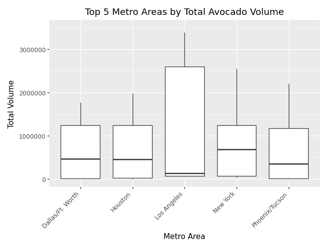

```python
# graph
(
    ggplot(top5_data, aes(x="geography", y="total_volume")) +
    geom_boxplot() +
    labs(
        title="Top 5 Metro Areas by Total Avocado Volume",
        x="Metro Area",
        y="Total Volume"
    ) +
    scale_y_continuous(limits=(0, 3500000)) +
    theme(axis_text_x=element_text(rotation=45, hjust=1))
)
```

6. From your cleaned data set, create a data set with only these California regions and answer the following questions about these California regions only.

```python
cali = avo_clean[avo_clean["geography"].isin(["Los Angeles", "San Diego", "Sacramento", "San Francisco"])]
cali.head()
```

|  | date | average_price | total_volume | total_small_avocados | total_medium_avocados | total_large_avocados | total_bags | small_bags | large_bags | xlarge_bags | type (C / O) | year | geography | geo_type | month | day |
| --- | --- | --- | --- | --- | --- | --- | --- | --- | --- | --- | --- | --- | --- | --- | --- | --- |
| 44 | 2015-01-04 | 0.85 | 2682159.95 | 1837999.65 | 524430.47 | 64225.78 | 255504.05 | 215571.80 | 36981.72 | 2950.53 | conventional | 2015 | Los Angeles | city | 1 | 4 |
| 45 | 2015-01-04 | 1.25 | 54495.54 | 47721.51 | 1723.40 | 0.00 | 5050.63 | 5050.63 | 0.00 | 0.00 | organic | 2015 | Los Angeles | city | 1 | 4 |
| 80 | 2015-01-04 | 1.05 | 430138.88 | 110693.69 | 270107.61 | 9737.50 | 39600.08 | 39600.08 | 0.00 | 0.00 | conventional | 2015 | Sacramento | city | 1 | 4 |
| 81 | 2015-01-04 | 1.33 | 9213.49 | 3727.52 | 4327.52 | 0.00 | 1158.45 | 1158.45 | 0.00 | 0.00 | organic | 2015 | Sacramento | city | 1 | 4 |
| 82 | 2015-01-04 | 0.94 | 461607.33 | 244152.26 | 165299.33 | 15302.75 | 36852.99 | 30884.29 | 5595.00 | 373.70 | conventional | 2015 | San Diego | city | 1 | 4 |

7. In which California regions is the price of organic versus conventional avocados most different? Support your answer with a few summary statistics AND a visualization.

```python
# I needed to look up the "unstack" funciton for this function
# Summary statistics
cali_price_diff = (
    cali.groupby(["geography", "type (C / O)"])["average_price"]
    .mean()
    .unstack()
)

cali_price_diff["price_diff"] = (
    cali_price_diff["organic"] - cali_price_diff["conventional"]
)

cali_price_diff
```

| type (C / O) geography | conventional | organic | price_diff |
| --- | --- | --- | --- |
| Los Angeles | 1.047124 | 1.574902 | 0.527778 |
| Sacramento | 1.295359 | 1.873856 | 0.578497 |
| San Diego | 1.113856 | 1.798366 | 0.684510 |
| San Francisco | 1.400490 | 2.119444 | 0.718954 |

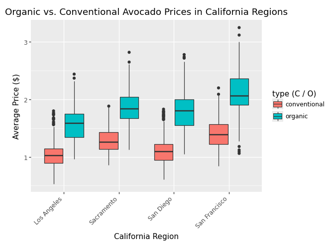

```python
# I needed to look up how to add the titles and axix labels
# Visualization
(
    ggplot(cali, aes(x="geography", y="average_price", fill="type (C / O)"))
    + geom_boxplot()
    + labs(
        title="Organic vs. Conventional Avocado Prices in California Regions",
        x="California Region",
        y="Average Price ($)"
    )
    + theme(axis_text_x=element_text(rotation=45, hjust=1))
)
```

8. The following plot shows, for all four California regions, the proportion of the average Hass avocado sales that are small, large, or extra large; conventional vs. organic. Recreate the plot; you do not have to replicate the exact finishing touches - e.g., color, theme - but your plot should resemble the content of this plot.

```python
cali.head()
```

|  | date | average_price | total_volume | total_small_avocados | total_medium_avocados | total_large_avocados | total_bags | small_bags | large_bags | xlarge_bags | type (C / O) | year | geography | geo_type | month | day |
| --- | --- | --- | --- | --- | --- | --- | --- | --- | --- | --- | --- | --- | --- | --- | --- | --- |
| 44 | 2015-01-04 | 0.85 | 2682159.95 | 1837999.65 | 524430.47 | 64225.78 | 255504.05 | 215571.80 | 36981.72 | 2950.53 | conventional | 2015 | Los Angeles | city | 1 | 4 |
| 45 | 2015-01-04 | 1.25 | 54495.54 | 47721.51 | 1723.40 | 0.00 | 5050.63 | 5050.63 | 0.00 | 0.00 | organic | 2015 | Los Angeles | city | 1 | 4 |
| 80 | 2015-01-04 | 1.05 | 430138.88 | 110693.69 | 270107.61 | 9737.50 | 39600.08 | 39600.08 | 0.00 | 0.00 | conventional | 2015 | Sacramento | city | 1 | 4 |
| 81 | 2015-01-04 | 1.33 | 9213.49 | 3727.52 | 4327.52 | 0.00 | 1158.45 | 1158.45 | 0.00 | 0.00 | organic | 2015 | Sacramento | city | 1 | 4 |
| 82 | 2015-01-04 | 0.94 | 461607.33 | 244152.26 | 165299.33 | 15302.75 | 36852.99 | 30884.29 | 5595.00 | 373.70 | conventional | 2015 | San Diego | city | 1 | 4 |

```python
# Transforming the data
cali_long = cali.melt(
    id_vars=["geography", "type (C / O)"],
    value_vars=["total_small_avocados", "total_medium_avocados", "total_large_avocados"],
    var_name="size",
    value_name="sales"
)
```

```python
# Test
cali_long
```

|  | geography | type (C / O) | size | sales |
| --- | --- | --- | --- | --- |
| 0 | Los Angeles | conventional | total_small_avocados | 1837999.65 |
| 1 | Los Angeles | organic | total_small_avocados | 47721.51 |
| 2 | Sacramento | conventional | total_small_avocados | 110693.69 |
| 3 | Sacramento | organic | total_small_avocados | 3727.52 |
| 4 | San Diego | conventional | total_small_avocados | 244152.26 |
| ... | ... | ... | ... | ... |
| 7339 | Sacramento | organic | total_large_avocados | 0.00 |
| 7340 | San Diego | conventional | total_large_avocados | 7210.47 |
| 7341 | San Diego | organic | total_large_avocados | 0.00 |
| 7342 | San Francisco | conventional | total_large_avocados | 5597.21 |
| 7343 | San Francisco | organic | total_large_avocados | 0.00 |

7344 rows × 4 columns

```python
# I looked up how to make transformaitons to the data during this step
# Proportion of sizes per region
cali_long["proportion"] = cali_long.groupby(["type (C / O)", "geography"])["sales"].transform(lambda x: x / x.sum())
```

```python
# Combining Type and Region
cali_long["type_region"] = cali_long["type (C / O)"] + " - " + cali_long["geography"]
```

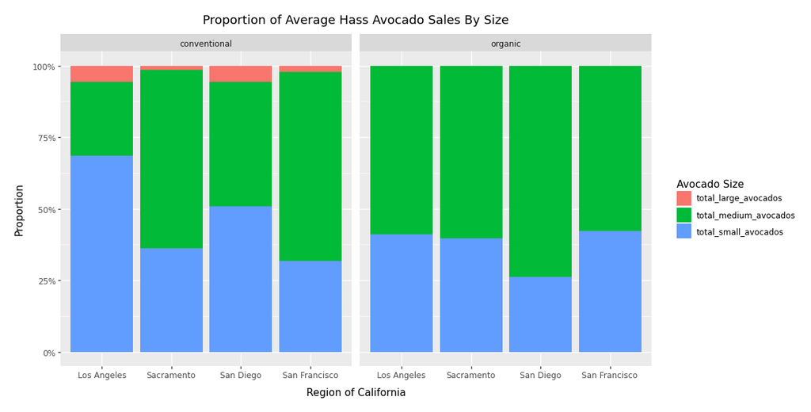

```python
# I looked up how to make more visually apealing (separating the bars into 2 sections, labeling each bar individually)
# Visualization
(
    ggplot(cali_long, aes(x="geography", y="proportion", fill="size"))
    + geom_bar(stat="identity")
    + facet_grid(". ~ type (C / O)")
    + labs(
        title="Proportion of Average Hass Avocado Sales By Size",
        x="Region of California",
        y="Proportion",
        fill="Avocado Size"
    )
    + scale_y_continuous(labels=lambda l: ["{:.0f}%".format(v*100) for v in l])
    + theme(figure_size=(12,6))
)
```

Find or assemble a data set of real data, with house prices for these four California regions. Join this data set with your California avocado data set.

Use your new joined data set to make an argument about the relationship between house prices and avocado prices/sales.

Support your argument with a plot.

```python
# Housing data
home = pd.read_csv("HousingPriceIndex.csv")
home.head()
```

|  | hpi_type | hpi_flavor | frequency | level | place_name | place_id | yr | period | index_nsa | index_sa |
| --- | --- | --- | --- | --- | --- | --- | --- | --- | --- | --- |
| 0 | NaN | NaN | NaN | NaN | NaN | NaN | NaN | NaN | NaN | NaN |
| 1 | traditional | purchase-only | monthly | USA or Census Division | East North Central Division | DV_ENC | 1991.0 | 1.0 | 100.00 | 100.00 |
| 2 | NaN | NaN | NaN | NaN | NaN | NaN | NaN | NaN | NaN | NaN |
| 3 | traditional | purchase-only | monthly | USA or Census Division | East North Central Division | DV_ENC | 1991.0 | 2.0 | 100.87 | 100.87 |
| 4 | NaN | NaN | NaN | NaN | NaN | NaN | NaN | NaN | NaN | NaN |

```python
# Cleaning of NaN values (because every other value was blank in the excel spreadsheet)
home = home.dropna()
home.head()
```

|  | hpi_type | hpi_flavor | frequency | level | place_name | place_id | yr | period | index_nsa | index_sa |
| --- | --- | --- | --- | --- | --- | --- | --- | --- | --- | --- |
| 1 | traditional | purchase-only | monthly | USA or Census Division | East North Central Division | DV_ENC | 1991.0 | 1.0 | 100.00 | 100.00 |
| 3 | traditional | purchase-only | monthly | USA or Census Division | East North Central Division | DV_ENC | 1991.0 | 2.0 | 100.87 | 100.87 |
| 5 | traditional | purchase-only | monthly | USA or Census Division | East North Central Division | DV_ENC | 1991.0 | 3.0 | 101.33 | 100.90 |
| 7 | traditional | purchase-only | monthly | USA or Census Division | East North Central Division | DV_ENC | 1991.0 | 4.0 | 101.73 | 100.97 |
| 9 | traditional | purchase-only | monthly | USA or Census Division | East North Central Division | DV_ENC | 1991.0 | 5.0 | 102.32 | 101.31 |

```python
# Regions
home_regions = ["San Francisco-San Mateo-Redwood City, CA (MSAD)", "San Diego-Chula Vista-Carlsbad, CA", "Sacramento-Roseville-Folsom, CA", "Los Angeles-Long Beach-Glendale, CA (MSAD)"]
```

```python
# Renaming columns to match
home = home.rename(columns={"place_name": "geography", "yr": "year"})
home.head()
```

|  | hpi_type | hpi_flavor | frequency | level | geography | place_id | year | period | index_nsa | index_sa |
| --- | --- | --- | --- | --- | --- | --- | --- | --- | --- | --- |
| 1 | traditional | purchase-only | monthly | USA or Census Division | East North Central Division | DV_ENC | 1991.0 | 1.0 | 100.00 | 100.00 |
| 3 | traditional | purchase-only | monthly | USA or Census Division | East North Central Division | DV_ENC | 1991.0 | 2.0 | 100.87 | 100.87 |
| 5 | traditional | purchase-only | monthly | USA or Census Division | East North Central Division | DV_ENC | 1991.0 | 3.0 | 101.33 | 100.90 |
| 7 | traditional | purchase-only | monthly | USA or Census Division | East North Central Division | DV_ENC | 1991.0 | 4.0 | 101.73 | 100.97 |
| 9 | traditional | purchase-only | monthly | USA or Census Division | East North Central Division | DV_ENC | 1991.0 | 5.0 | 102.32 | 101.31 |

```python
# Get rid of useless columns
home = home.drop(columns = {"hpi_type", "hpi_flavor", "level", "place_id", "index_sa"})
home.head()
```

|  | frequency | geography | year | period | index_nsa |
| --- | --- | --- | --- | --- | --- |
| 1 | monthly | East North Central Division | 1991.0 | 1.0 | 100.00 |
| 3 | monthly | East North Central Division | 1991.0 | 2.0 | 100.87 |
| 5 | monthly | East North Central Division | 1991.0 | 3.0 | 101.33 |
| 7 | monthly | East North Central Division | 1991.0 | 4.0 | 101.73 |
| 9 | monthly | East North Central Division | 1991.0 | 5.0 | 102.32 |

```python
# Renaming regions
home["geography"] = home["geography"].replace({
    "San Francisco-San Mateo-Redwood City, CA (MSAD)" : "San Francisco",
    "San Diego-Chula Vista-Carlsbad, CA" : "San Diego",
    "Sacramento-Roseville-Folsom, CA" : "Sacramento",
    "Los Angeles-Long Beach-Glendale, CA (MSAD)" : "Los Angeles"
})
```

```python
# Removing all but the locations we want
home = home[home["geography"].isin(["San Francisco", "San Diego", "Sacramento", "Los Angeles"])]
home
```

|  | frequency | geography | year | period | index_nsa |
| --- | --- | --- | --- | --- | --- |
| 178119 | quarterly | Los Angeles | 1991.0 | 1.0 | 100.00 |
| 178121 | quarterly | Los Angeles | 1991.0 | 2.0 | 100.09 |
| 178123 | quarterly | Los Angeles | 1991.0 | 3.0 | 100.72 |
| 178125 | quarterly | Los Angeles | 1991.0 | 4.0 | 99.83 |
| 178127 | quarterly | Los Angeles | 1992.0 | 1.0 | 97.47 |
| ... | ... | ... | ... | ... | ... |
| 262021 | quarterly | San Francisco | 2024.0 | 2.0 | 524.91 |
| 262023 | quarterly | San Francisco | 2024.0 | 3.0 | 519.31 |
| 262025 | quarterly | San Francisco | 2024.0 | 4.0 | 514.75 |
| 262027 | quarterly | San Francisco | 2025.0 | 1.0 | 518.64 |
| 262029 | quarterly | San Francisco | 2025.0 | 2.0 | 552.01 |

1380 rows × 5 columns

```python
# Make housing annual
home = (home.groupby(["geography"])["index_nsa"].mean().reset_index())
home.head()
```

|  | geography | index_nsa |
| --- | --- | --- |
| 0 | Los Angeles | 208.116449 |
| 1 | Sacramento | 189.943986 |
| 2 | San Diego | 236.391739 |
| 3 | San Francisco | 270.856957 |

```python
# Merge tables
homeacado = cali_long.merge(home, left_on = ["geography"], right_on = ["geography"])
homeacado
```

|  | geography | type (C / O) | size | sales | proportion | type_region | index_nsa |
| --- | --- | --- | --- | --- | --- | --- | --- |
| 0 | Los Angeles | conventional | total_small_avocados | 1837999.65 | 0.003505 | conventional - Los Angeles | 208.116449 |
| 1 | Los Angeles | organic | total_small_avocados | 47721.51 | 0.004424 | organic - Los Angeles | 208.116449 |
| 2 | Sacramento | conventional | total_small_avocados | 110693.69 | 0.000926 | conventional - Sacramento | 189.943986 |
| 3 | Sacramento | organic | total_small_avocados | 3727.52 | 0.001718 | organic - Sacramento | 189.943986 |
| 4 | San Diego | conventional | total_small_avocados | 244152.26 | 0.002479 | conventional - San Diego | 236.391739 |
| ... | ... | ... | ... | ... | ... | ... | ... |
| 7339 | Sacramento | organic | total_large_avocados | 0.00 | 0.000000 | organic - Sacramento | 189.943986 |
| 7340 | San Diego | conventional | total_large_avocados | 7210.47 | 0.000073 | conventional - San Diego | 236.391739 |
| 7341 | San Diego | organic | total_large_avocados | 0.00 | 0.000000 | organic - San Diego | 236.391739 |
| 7342 | San Francisco | conventional | total_large_avocados | 5597.21 | 0.000027 | conventional - San Francisco | 270.856957 |
| 7343 | San Francisco | organic | total_large_avocados | 0.00 | 0.000000 | organic - San Francisco | 270.856957 |

7344 rows × 7 columns

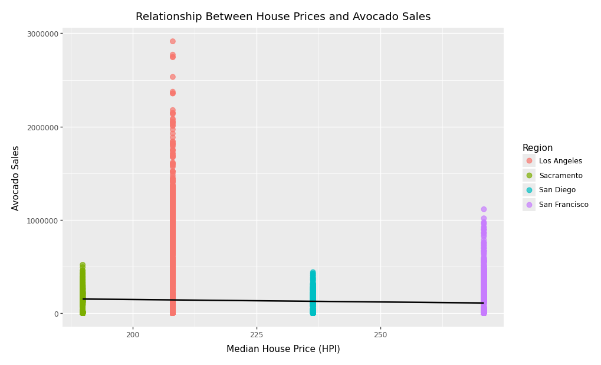

```python
# Visualization
(
    ggplot(homeacado, aes(x="index_nsa", y="sales", color="geography"))
    + geom_point(size=3, alpha=0.7)
    + geom_smooth(method="lm", se=True, color="black")
    + labs(
        title="Relationship Between House Prices and Avocado Sales",
        x="Median House Price (HPI)",
        y="Avocado Sales",
        color="Region"
    )
    + theme(figure_size=(10,6))
)
```

As we could probably guess, from my research and visualization created because of it, there is no relationship between house prices and avocado prices/ sales. This must mean that millennials can continue spending their money on avo toast.